# Patnaik_Project_1_v2

Smitali Patnaik

2022-09-12

## OVERVIEW

This project comprises of writing functions that will manipulate and process data sets that come in a certain form and obtain plots through generic function. The data set is read in the form of csv from the given url link. It is then converter to long format with select columns taken into a data frame. Some operations are performed to get required format and new columns are generated where required,The overall data set is then split to get final county and state data frames which are then used to obtain plots after performing statistical operations.

The use of chain has been adopted in most of the cases except a few code chunks.

First, all the functions having the steps have been defined with the wrapper function and binding function in DATA PROCESSING AND FUCNTION DECLARATIONS part. All the plots for state and counties are created in GENERIC FUNCTION TO SUMMARIZE DATA. Finally, in ALL FUNCTION CALL AND OUTOUT, the EDU01 and PST01 data sets are taken and all above functions are called and output is generated.

## DATA PROCESSING AND FUNCTION DECLARATIONS

### Get Packages

Get all useful packages all together. To ensure the code runs smooth we are getting all library packages all together to do the useful work.

```r
library(readr)
library(dplyr)
library(tidyr)
library(tidyverse)
library(ggplot2)
```

#### Step 1 and 2

After the csv is read and the raw data set is sent here for getting select columns Area_name. STCOU and Any column that ends with “D”. The raw data is turned from wide to long format with new column called “Enrollment” (used in function call and set here at new_value) The output is used in next function

```r
step_1_2<- function(sheet1,new_value=0) {
  datasheet1 <- sheet1 %>% select(Area_name,STCOU,ends_with("D"))
  df<- datasheet1 %>% pivot_longer(cols = 3:12, names_to = new_value, values_to = "Values")
  return(df)
}
```

#### Step 3

Here, the Enrollment column newly created is used to get first 3 characters and next 4 digits to get another column called Measurement using mutate and substr(). Similarly, the Enrollment column is used to get Year from the last two digits and then 4 digit Year is created using ifelse. The 2 digits are added to 2000 if they are between 0 to 22 to get Year in 2000s or else they are added to 1900 to get year in 1900s.

```r
step_3<-function(df) {
  # two digits before ('D') for year column.
  df1<-df %>% mutate(Yearx=substr(Enrollment,8,9))
  # getting 1st three letters and following 4 digits
  df1<-df1 %>% mutate(Measurement=substr(Enrollment,1,7))
  df2<-df1 %>% separate(Yearx,c("Yearx"),convert=TRUE,remove=TRUE)
  # using ifelse statement to get dates in 4 digits.
  df3<- df2 %>% mutate(Year=ifelse(Yearx>=0 & Yearx <=22 ,2000+Yearx,Yearx+1900))
  df3<-df3 %>% select(Area_name,STCOU,Enrollment,Values,Measurement,Year) # final data frame.
  return (df3)
}
```

#### Step 4

In this step, two data sets are created - one data set contains only non-county data and other data set contains only county level data. Command called ‘grep’ is used to match the pattern in the Area_name to get county data set and this case has been simply inverted to get state data (all that does not match the pattern given in grep) Also, class is added to both the data sets using the code in instructions. Both these steps are implemented through functions step_4_1 and step_4_2. This is done this way because a single function cannot return two data frames in R. The class type needs to be converted to some other object. In this case class result needs to be preserved for further steps.

```r
step_4_1<-function(df3) {
     #getting county data sets.
     # this gives all the rows matching format 'county name,DD'
    county<- df3[grep(pattern = ", \\w\\w",df3$Area_name),]
    # creating class below
    class(county) <- c("county", class(county))
    return(county)
  }
```

```r
step_4_2<-function(df3) {
  #getting all state datasets.
    # gives all the rows not matching format 'county name,DD'
    state<-  df3[grep(pattern = ", \\w\\w",invert=TRUE,df3$Area_name),]
    # creating class below
    class(state) <- c("state", class(state))
    return(state)

}
```

#### Step 5

From the county data set, new column called ‘State’ is created that takes the last two abbreviations from the Area_name and gets added to the corresponding county. The step is done using substr and nchar - where nchar is used to get the total number of strings for each row of Area_name and this length and its 2nd value is used to extract the last two abbreviations using a length-1 formulation.

```r
step_5<-function(county){
  # Using substr and nchar here to get new column
  county_df<- county %>% mutate(State=substr(Area_name,(nchar(Area_name)-1),nchar(Area_name)))
  return(county_df)
}
```

#### Step 6

This step creates another column called ‘Division’ for each of the states mentioned in Area_name. First a vector is created here to get each division. And using if else statement the corresponding divisions are matched and added to each state. Both Area_name and Divisions have been converted to lowercase to ensure the case sensitivity is removed.

```r
step_6<-function(state) {
  # Getting all the Divisions here.
  New_England=c('Connecticut', 'Maine', 'Massachusetts', 'New Hampshire', 'Rhode Island',
                'Vermont')
  Mid_Atlantic=c('(New Jersey', 'New York', 'Pennsylvania')
  East_North_Central=c('Illinois','Indiana', 'Michigan', 'Ohio','Wisconsin')
  West_North_Central=c('Iowa', 'Kansas', 'Minnesota', 'Missouri', 'Nebraska', 'North Dakota',
                       'South Dakota')
  South_Atlantic=c('Delaware','Florida', 'Georgia', 'Maryland', 'North Carolina',
                   'South Carolina', 'Virginia', 'District of Columbia', 'West Virginia')
  East_South_Central=c('Alabama', 'Kentucky', 'Mississippi', 'Tennessee')
  West_South_Central=c('Arkansas', 'Louisiana', 'Oklahoma', 'Texas')
  Mountain=c('Arizona', 'Colorado', 'Idaho', 'Montana', 'Nevada', 'New Mexico', 'Utah',
             'Wyoming')
  Pacific=c('Alaska', 'California', 'Hawaii', 'Oregon', 'Washington')

  # Using if else to allot the Divisions to each row of the Area_name at the new column 'Division'
  state_df<-state %>%
      mutate(Division=ifelse(tolower(Area_name)%in% tolower(New_England),"New England",
                      ifelse(tolower(Area_name)%in% tolower(Mid_Atlantic),"Mid Atlantic",
                        ifelse(tolower(Area_name)%in% tolower(East_North_Central),"East North Central",
                         ifelse(tolower(Area_name)%in% tolower(West_North_Central),"West North Central",
                          ifelse(tolower(Area_name)%in% tolower(South_Atlantic),"South Atlantic",
                           ifelse(tolower(Area_name)%in% tolower(East_South_Central),"East South Central",
                            ifelse(tolower(Area_name)%in% tolower(West_South_Central),"West South Central",
                             ifelse(tolower(Area_name)%in% tolower(Mountain),"Mountain",
                              ifelse(tolower(Area_name)%in% tolower(Pacific),"Pacific","ERROR"))))))))))
  return(state_df) # final output
}
```

#### A call function for step 4,5 and 6.

Using the output from step 3, function 4 is called to perform step 4 and step 5 and 6 functions are called.

```r
step_4_5_6<-function(df3_out) {
  # Calling step_4 using output from step 3. Output returned is two data sets.
  answer_step4_county<-step_4_1(df3_out)
  answer_step4_state<-step_4_2(df3_out)

  county<-answer_step4_county #county dataset extracted from step 4 output
  state<-answer_step4_state # state dataset extracted from step 4 output.

  county1<-step_5(county) # step 5 called
  state1<-step_6(state) # step 6 called
  # Two dataframes cannot be returned seprately in R. Needs conversion.
  return(list(county1,state1))

}
```

#### Function WRAPPER

This is the last function wrapper to combine all the function calls in a single function. This wrapper function is soley called for each dataset. This generalizes the entire process and makes it suitable for all the data sets of similar structure. This Wrappper function uses new name “Enrollment” used in Step 2 to give name to the new column after long format conversion.

```r
my_wrapper <- function(file, new_value = 0)
  {
    # the csv file from url read here.
  csv_df <- read_csv(file,show_col_types = FALSE)
  # step 1 & 2 calls
  outdf_step_1_2 <- step_1_2(csv_df,new_value)
  # step step 3 call
  out_df_step_3 <- step_3(outdf_step_1_2)
  # last function call processing step 4 ,5, and 6.
  out_df_step_4_5_6 <- step_4_5_6(out_df_step_3)
  return (out_df_step_4_5_6)
}
```

### BINDING WORK

The wrappper function is called two times for two sets of URLs , So , we have two sets of output from each URL, county and state. The county data from both URLs are combined , and similarly state data from both the URLs are combined. his function will be called 2 times i.e one time for combining county data and one time for combining state data. This uses ‘bind_rows’ to do the combination i.e bind_rows(county_data_from_file1,county_data_from_file2).Also, this function takes data from output of function wrapper as list as it is cumbersome to to call combined/binding function like combined(edu01a[[1]],edu01b[[1]]) for each dataset. So simple list county data is simply taken as a list argument and converted to dataframe again to get the county /state data from respective two files. #### Binding Function

```r
  combined<-function(dataset1,dataset2) {
  datasheet1<-data.frame(dataset1)

  datasheet2<-data.frame(dataset2)
  combined_out<-dplyr::bind_rows(dataset1,dataset2)
  return(combined_out)
}
```

## GENERIC FUNCTION TO SUMMARIZE DATA

### ALL PLOT FUNCTIONS

All the plot functions are defined here. This comprises of plots for statistics obtained for county and state datasets finally ready after combination from respective URLs.

#### State Plots

State Plots have rows removed that have ‘ERROR’ value in division and the data is grouped by Divison and Year. Mean is calculated for the Values based on this grouping and graph is generated. The state plot function is called with required parameters passed - state_dataset and ‘var_name’ that has Values column. The plot is set to have X axis as Year , Y axis as the mean.

```r
  plot.state=function(df_state,var_name=NULL){
  # Removing ERROR Divisions
  state_df<-df_state %>% filter(!Division%in% c("ERROR"))
  # Grouping and Mean calculation
  state_mean<-state_df %>% group_by(Division,Year) %>% summarise(Mean_Value=mean(get(var_name)))
  ggplot (state_mean, aes(x = Year, y = Mean_Value, color = Division))+geom_line()
}
```

#### County Plots

County Plots have some additional processing prior to the ggplot. This has some default values already set as per instructions if user specified inputs are not passed into the function. The mean statistic is calculated based on the Area_name. The data set is then sorted based on the user provided inputs ‘top’ or ‘bottom’ and x number of rows are filtered and stored in the final filtered data frame which is then used for the plots. The variables passed by the user are : 1) ‘State’- default value is ‘AL’, this only displays county rows corresponding to the State passed by the user. 2) ‘how’ sorts the data set on statistic as descending for ‘top’ or default ascending for ‘bottom’ with default being ‘top’ if, nothing is passed. The function prints ‘ERROR’ if anything else is passed. 3) x is the number of rows to be extracted from this result on which plotting is performed. default value is set to 5 as per instructions.

```r
plot.county=function(df_county,var_name=NULL,State='AL',how='top',x=5){
# Extracting data frame containing rows for required state only
county_df<-df_county[grep(pattern=State, df_county$Area_name),]
# Grouping and Mean

county_mean<-county_df %>% group_by(Area_name,Year) %>% summarise(Mean_Value=mean(get(var_name)))
# Adding the scenarios using if else.
if(tolower(how)=='bottom')
  {
   county_sorted<-filter(arrange(county_mean,Mean_Value))
   filtered_df<-head(county_sorted,x) # for bottom sort in ascending and take head
}

else if (tolower(how)=='top')
  {
  county_sorted<-filter(arrange(county_mean,desc(Mean_Value)))
  filtered_df<-head(county_sorted,x)
}

else {print("ERROR")}
ggplot (filtered_df, aes(x = Year, y = Mean_Value, color = Area_name)) +geom_line()

}
```

## ALL FUNCTION CALLS AND OUTPUTS

#### EDU01 DATASETS

#### EDU01a dataset processed from function wrapper.

Calling the edu01a dataset here. the output is county and state datasets for this URL.

```r
file1="https://www4.stat.ncsu.edu/~online/datasets/EDU01a.csv"
edu01a<-my_wrapper(file1,new_value="Enrollment")
print("County Frames")
```

```
## [1] "County Frames"
```

```r
head(edu01a[[1]],10)
```

| Area_name | STCOU | Enrollment | Values | Measurement | Year | State |
| --- | --- | --- | --- | --- | --- | --- |
| Autauga, AL | 01001 | EDU010187D | 6829 | EDU0101 | 1987 | AL |
| Autauga, AL | 01001 | EDU010188D | 6900 | EDU0101 | 1988 | AL |
| Autauga, AL | 01001 | EDU010189D | 6920 | EDU0101 | 1989 | AL |
| Autauga, AL | 01001 | EDU010190D | 6847 | EDU0101 | 1990 | AL |
| Autauga, AL | 01001 | EDU010191D | 7008 | EDU0101 | 1991 | AL |
| Autauga, AL | 01001 | EDU010192D | 7137 | EDU0101 | 1992 | AL |
| Autauga, AL | 01001 | EDU010193D | 7152 | EDU0101 | 1993 | AL |
| Autauga, AL | 01001 | EDU010194D | 7381 | EDU0101 | 1994 | AL |
| Autauga, AL | 01001 | EDU010195D | 7568 | EDU0101 | 1995 | AL |
| Autauga, AL | 01001 | EDU010196D | 7834 | EDU0101 | 1996 | AL |

```r
print("State Frames")
```

```
## [1] "State Frames"
```

```r
head(edu01a[[2]],10)
```

| Area_name | STCOU | Enrollment | Values | Measurement | Year | Division |
| --- | --- | --- | --- | --- | --- | --- |
| UNITED STATES | 00000 | EDU010187D | 40024299 | EDU0101 | 1987 | ERROR |
| UNITED STATES | 00000 | EDU010188D | 39967624 | EDU0101 | 1988 | ERROR |
| UNITED STATES | 00000 | EDU010189D | 40317775 | EDU0101 | 1989 | ERROR |
| UNITED STATES | 00000 | EDU010190D | 40737600 | EDU0101 | 1990 | ERROR |
| UNITED STATES | 00000 | EDU010191D | 41385442 | EDU0101 | 1991 | ERROR |
| UNITED STATES | 00000 | EDU010192D | 42088151 | EDU0101 | 1992 | ERROR |
| UNITED STATES | 00000 | EDU010193D | 42724710 | EDU0101 | 1993 | ERROR |
| UNITED STATES | 00000 | EDU010194D | 43369917 | EDU0101 | 1994 | ERROR |
| UNITED STATES | 00000 | EDU010195D | 43993459 | EDU0101 | 1995 | ERROR |
| UNITED STATES | 00000 | EDU010196D | 44715737 | EDU0101 | 1996 | ERROR |

#### EDU01b dataset processed from function wrapper.

Calling the edu01b dataset here. the output is county and state datasets for this URL.

```r
file2="https://www4.stat.ncsu.edu/~online/datasets/EDU01b.csv"
edu01b<-my_wrapper(file2,new_value="Enrollment")
print("County Frames")
```

```
## [1] "County Frames"
```

```r
head(edu01b[[1]],10)
```

| Area_name | STCOU | Enrollment | Values | Measurement | Year | State |
| --- | --- | --- | --- | --- | --- | --- |
| Autauga, AL | 01001 | EDU010197D | 8099 | EDU0101 | 1997 | AL |
| Autauga, AL | 01001 | EDU010198D | 8211 | EDU0101 | 1998 | AL |
| Autauga, AL | 01001 | EDU010199D | 8489 | EDU0101 | 1999 | AL |
| Autauga, AL | 01001 | EDU010200D | 8912 | EDU0102 | 2000 | AL |
| Autauga, AL | 01001 | EDU010201D | 8626 | EDU0102 | 2001 | AL |
| Autauga, AL | 01001 | EDU010202D | 8762 | EDU0102 | 2002 | AL |
| Autauga, AL | 01001 | EDU015203D | 9105 | EDU0152 | 2003 | AL |
| Autauga, AL | 01001 | EDU015204D | 9200 | EDU0152 | 2004 | AL |
| Autauga, AL | 01001 | EDU015205D | 9559 | EDU0152 | 2005 | AL |
| Autauga, AL | 01001 | EDU015206D | 9652 | EDU0152 | 2006 | AL |

```r
print("State Frames")
```

```
## [1] "State Frames"
```

```r
head(edu01b[[2]],10)
```

| Area_name | STCOU | Enrollment | Values | Measurement | Year | Division |
| --- | --- | --- | --- | --- | --- | --- |
| UNITED STATES | 00000 | EDU010197D | 44534459 | EDU0101 | 1997 | ERROR |
| UNITED STATES | 00000 | EDU010198D | 46245814 | EDU0101 | 1998 | ERROR |
| UNITED STATES | 00000 | EDU010199D | 46368903 | EDU0101 | 1999 | ERROR |
| UNITED STATES | 00000 | EDU010200D | 46818690 | EDU0102 | 2000 | ERROR |
| UNITED STATES | 00000 | EDU010201D | 47127066 | EDU0102 | 2001 | ERROR |
| UNITED STATES | 00000 | EDU010202D | 47606570 | EDU0102 | 2002 | ERROR |
| UNITED STATES | 00000 | EDU015203D | 48506317 | EDU0152 | 2003 | ERROR |
| UNITED STATES | 00000 | EDU015204D | 48693287 | EDU0152 | 2004 | ERROR |
| UNITED STATES | 00000 | EDU015205D | 48978555 | EDU0152 | 2005 | ERROR |
| UNITED STATES | 00000 | EDU015206D | 49140702 | EDU0152 | 2006 | ERROR |

#### Calling the Binding Function to combine these two datasets

Calling the Binding Function to combine the above two data sets. We county_all dataset and state_all data set as a result of this combination. Please note that the ed01a[1],edu01b[1] are extracted from the signle output comingout of the wrappper function. This has two dataframes returned together after combining them as list(data frame1,data frame2). This changes the class of the file edu01. And the respective data frame class can be accessed as edu[[1]]. The combine function already has data frame conversion built in. So we are calling sending this data to combine function in ease.

```r
county_all<-combined(edu01a[1],edu01b[1])
#print(county_all,n=10) # displaying first 10 rows
print("County Frames all combined")
```

```
## [1] "County Frames all combined"
```

```r
head(county_all,10)
```

| Area_name | STCOU | Enrollment | Values | Measurement | Year | State |
| --- | --- | --- | --- | --- | --- | --- |
| Autauga, AL | 01001 | EDU010187D | 6829 | EDU0101 | 1987 | AL |
| Autauga, AL | 01001 | EDU010188D | 6900 | EDU0101 | 1988 | AL |
| Autauga, AL | 01001 | EDU010189D | 6920 | EDU0101 | 1989 | AL |
| Autauga, AL | 01001 | EDU010190D | 6847 | EDU0101 | 1990 | AL |
| Autauga, AL | 01001 | EDU010191D | 7008 | EDU0101 | 1991 | AL |
| Autauga, AL | 01001 | EDU010192D | 7137 | EDU0101 | 1992 | AL |
| Autauga, AL | 01001 | EDU010193D | 7152 | EDU0101 | 1993 | AL |
| Autauga, AL | 01001 | EDU010194D | 7381 | EDU0101 | 1994 | AL |
| Autauga, AL | 01001 | EDU010195D | 7568 | EDU0101 | 1995 | AL |
| Autauga, AL | 01001 | EDU010196D | 7834 | EDU0101 | 1996 | AL |

```r
state_all<-combined(edu01a[2],edu01b[2])
# displaying first 10 rows
print("State Frames all combined ")
```

```
## [1] "State Frames all combined "
```

```r
head(state_all,10)
```

| Area_name | STCOU | Enrollment | Values | Measurement | Year | Division |
| --- | --- | --- | --- | --- | --- | --- |
| UNITED STATES | 00000 | EDU010187D | 40024299 | EDU0101 | 1987 | ERROR |
| UNITED STATES | 00000 | EDU010188D | 39967624 | EDU0101 | 1988 | ERROR |
| UNITED STATES | 00000 | EDU010189D | 40317775 | EDU0101 | 1989 | ERROR |
| UNITED STATES | 00000 | EDU010190D | 40737600 | EDU0101 | 1990 | ERROR |
| UNITED STATES | 00000 | EDU010191D | 41385442 | EDU0101 | 1991 | ERROR |
| UNITED STATES | 00000 | EDU010192D | 42088151 | EDU0101 | 1992 | ERROR |
| UNITED STATES | 00000 | EDU010193D | 42724710 | EDU0101 | 1993 | ERROR |
| UNITED STATES | 00000 | EDU010194D | 43369917 | EDU0101 | 1994 | ERROR |
| UNITED STATES | 00000 | EDU010195D | 43993459 | EDU0101 | 1995 | ERROR |
| UNITED STATES | 00000 | EDU010196D | 44715737 | EDU0101 | 1996 | ERROR |

#### Calling all the Plot Functions here for EDU dataset

The respective plots are called here. All the scenarios from the instructions displayed here.

#### State plots

Below are the results of the state_all plots. This shows that the Mean enrollments for the states in Mid-Atlantic divsion has always been higher as compared to the other Divisions. The reason for such high trend could be that these states have some large cities, due to which more educational set ups might be present. Lowest trend was observed for NeE England which are smaller states area wise.

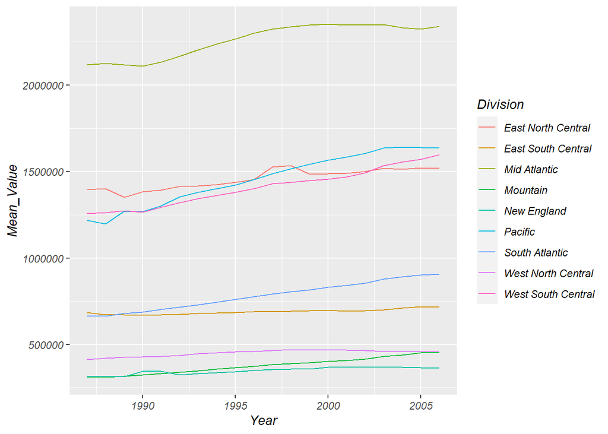

```r
plot.state(state_all, var_name = 'Values')
```

#### County Plot : specifying the state to be “PA”, the group being the ‘top’, the number looked at being 7 i.e x=7

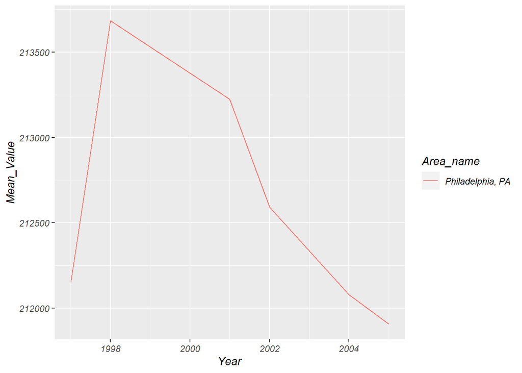

```r
plot.county(county_all, var_name = 'Values',State='PA',how='top',x=7)
```

#### County Plot : specifying the state to be “PA”, the group being the ‘bottom’, the number looked at being 4 i.e x=4

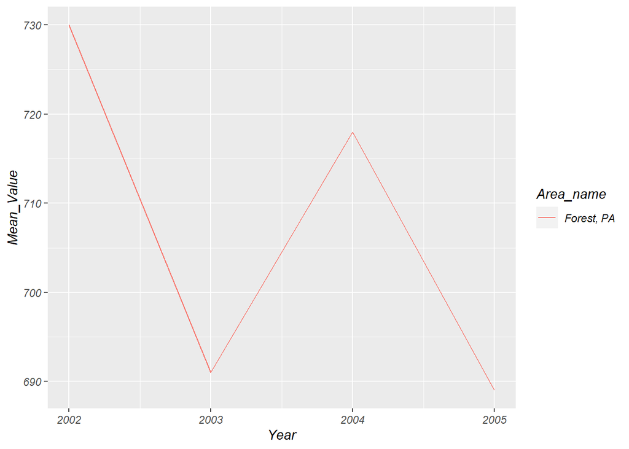

```r
plot.county(county_all, var_name = 'Values',State='PA',how='bottom',x=4)
```

#### County Plot : without specifying anything (defaults used). State taken is ‘AL’ , ‘how’= ‘top’ and x=5.

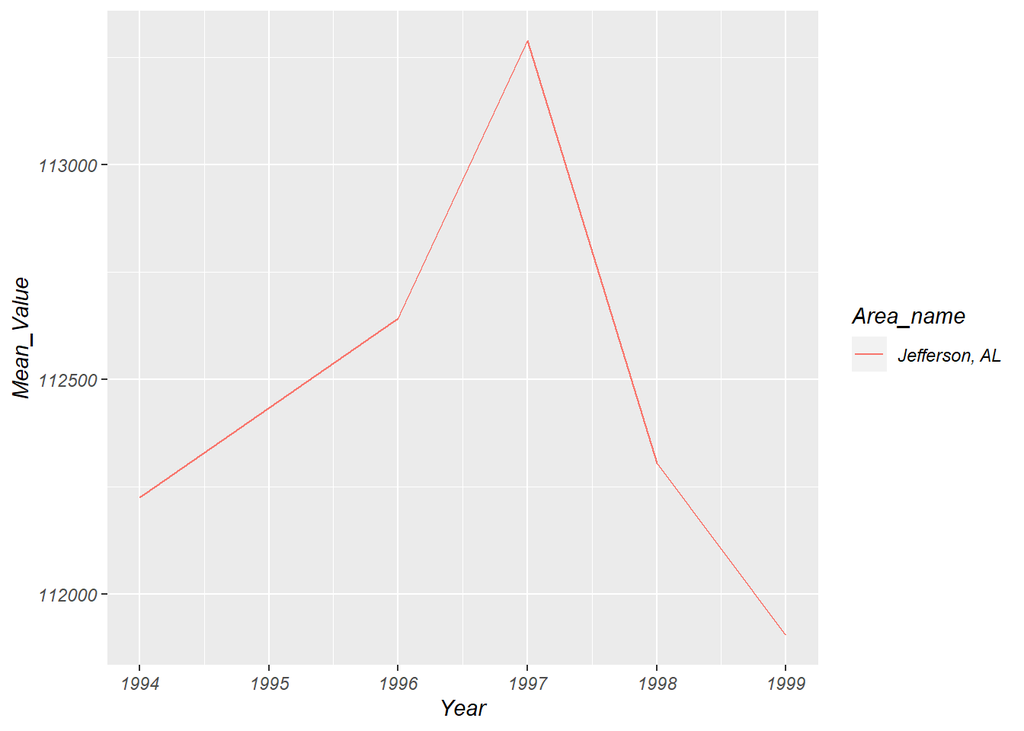

```r
plot.county(county_all, var_name = 'Values')
```

#### County Plot : specifying the state to be “MN”, the group being the ‘top’, the number looked at being 10 i.e x=10

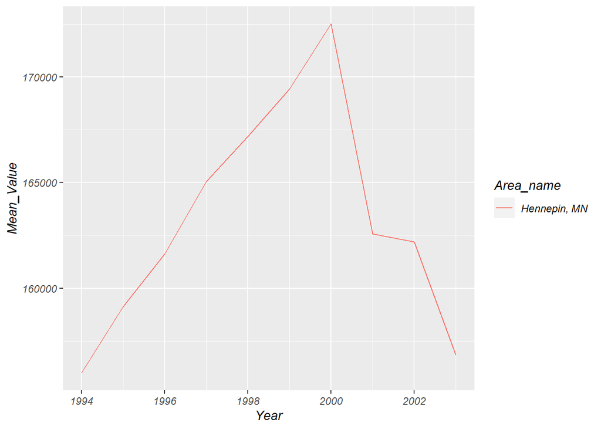

```r
plot.county(county_all, var_name = 'Values',State='MN',how='top',x=10)
```

#### PST01 DATASETS

#### PST01a,PST01b,PST01c,PST01d datasets processed from function wrapper.

The other 4 data sets being read are from PST01. Similar steps are implemented here as above. The function uses my_wrapper function to store outputs in pst0x named files. pst_county files use combined function to get the single county /state files. There is an extra combined step for both state and county files to get final file as we have 4 raw file to combine here. And our combine function can take only two files at a time.

```r
file3<-"https://www4.stat.ncsu.edu/~online/datasets/PST01a.csv"
file4<- "https://www4.stat.ncsu.edu/~online/datasets/PST01b.csv"
file5<- "https://www4.stat.ncsu.edu/~online/datasets/PST01c.csv"
file6<-"https://www4.stat.ncsu.edu/~online/datasets/PST01d.csv"

#Getting outputs for the function calls-pst01a
pst01a<-my_wrapper(file3,new_value="Enrollment")
print("County Frames-pst01a")
```

```
## [1] "County Frames-pst01a"
```

```r
head(pst01a[[1]],10) # Displaying first 10 values
```

| Area_name | STCOU | Enrollment | Values | Measurement | Year | State |
| --- | --- | --- | --- | --- | --- | --- |
| Autauga, AL | 01001 | PST015171D | 25508 | PST0151 | 1971 | AL |
| Autauga, AL | 01001 | PST015172D | 27166 | PST0151 | 1972 | AL |
| Autauga, AL | 01001 | PST015173D | 28463 | PST0151 | 1973 | AL |
| Autauga, AL | 01001 | PST015174D | 29266 | PST0151 | 1974 | AL |
| Autauga, AL | 01001 | PST015175D | 29718 | PST0151 | 1975 | AL |
| Autauga, AL | 01001 | PST015176D | 29896 | PST0151 | 1976 | AL |
| Autauga, AL | 01001 | PST015177D | 30462 | PST0151 | 1977 | AL |
| Autauga, AL | 01001 | PST015178D | 30882 | PST0151 | 1978 | AL |
| Autauga, AL | 01001 | PST015179D | 32055 | PST0151 | 1979 | AL |
| Autauga, AL | 01001 | PST025181D | 31985 | PST0251 | 1981 | AL |

```r
print("State Frames-pst01a")
```

```
## [1] "State Frames-pst01a"
```

```r
head(pst01a[[2]],10) # Displaying first 10 values
```

| Area_name | STCOU | Enrollment | Values | Measurement | Year | Division |
| --- | --- | --- | --- | --- | --- | --- |
| UNITED STATES | 00000 | PST015171D | 206827028 | PST0151 | 1971 | ERROR |
| UNITED STATES | 00000 | PST015172D | 209283904 | PST0151 | 1972 | ERROR |
| UNITED STATES | 00000 | PST015173D | 211357490 | PST0151 | 1973 | ERROR |
| UNITED STATES | 00000 | PST015174D | 213341552 | PST0151 | 1974 | ERROR |
| UNITED STATES | 00000 | PST015175D | 215465246 | PST0151 | 1975 | ERROR |
| UNITED STATES | 00000 | PST015176D | 217562728 | PST0151 | 1976 | ERROR |
| UNITED STATES | 00000 | PST015177D | 219759860 | PST0151 | 1977 | ERROR |
| UNITED STATES | 00000 | PST015178D | 222095080 | PST0151 | 1978 | ERROR |
| UNITED STATES | 00000 | PST015179D | 224567234 | PST0151 | 1979 | ERROR |
| UNITED STATES | 00000 | PST025181D | 229466391 | PST0251 | 1981 | ERROR |

```r
#Getting outputs for the function calls-pst01b
pst01b<-my_wrapper(file4,new_value="Enrollment")
print("County Frames-pst01b")
```

```
## [1] "County Frames-pst01b"
```

```r
head(pst01b[[1]],10) # Displaying first 10 values
```

| Area_name | STCOU | Enrollment | Values | Measurement | Year | State |
| --- | --- | --- | --- | --- | --- | --- |
| Autauga, AL | 01001 | PST025182D | 32038 | PST0251 | 1982 | AL |
| Autauga, AL | 01001 | PST025183D | 32057 | PST0251 | 1983 | AL |
| Autauga, AL | 01001 | PST025184D | 32130 | PST0251 | 1984 | AL |
| Autauga, AL | 01001 | PST025185D | 32248 | PST0251 | 1985 | AL |
| Autauga, AL | 01001 | PST025186D | 32895 | PST0251 | 1986 | AL |
| Autauga, AL | 01001 | PST025187D | 33266 | PST0251 | 1987 | AL |
| Autauga, AL | 01001 | PST025188D | 33637 | PST0251 | 1988 | AL |
| Autauga, AL | 01001 | PST025189D | 33996 | PST0251 | 1989 | AL |
| Autauga, AL | 01001 | PST030190D | 34222 | PST0301 | 1990 | AL |
| Autauga, AL | 01001 | PST035190D | 34353 | PST0351 | 1990 | AL |

```r
print("State Frames-pst01b")
```

```
## [1] "State Frames-pst01b"
```

```r
head(pst01b[[2]],10) # Displaying first 10 values
```

| Area_name | STCOU | Enrollment | Values | Measurement | Year | Division |
| --- | --- | --- | --- | --- | --- | --- |
| UNITED STATES | 00000 | PST025182D | 231665106 | PST0251 | 1982 | ERROR |
| UNITED STATES | 00000 | PST025183D | 233792697 | PST0251 | 1983 | ERROR |
| UNITED STATES | 00000 | PST025184D | 235825544 | PST0251 | 1984 | ERROR |
| UNITED STATES | 00000 | PST025185D | 237924311 | PST0251 | 1985 | ERROR |
| UNITED STATES | 00000 | PST025186D | 240133472 | PST0251 | 1986 | ERROR |
| UNITED STATES | 00000 | PST025187D | 242289738 | PST0251 | 1987 | ERROR |
| UNITED STATES | 00000 | PST025188D | 244499776 | PST0251 | 1988 | ERROR |
| UNITED STATES | 00000 | PST025189D | 246819839 | PST0251 | 1989 | ERROR |
| UNITED STATES | 00000 | PST030190D | 248790925 | PST0301 | 1990 | ERROR |
| UNITED STATES | 00000 | PST035190D | 249622814 | PST0351 | 1990 | ERROR |

```r
#Getting outputs for the function calls-pst01c
pst01c<-my_wrapper(file5,new_value="Enrollment")
print("County Frames-pst01c")
```

```
## [1] "County Frames-pst01c"
```

```r
head(pst01c[[1]],10) # Displaying first 10 values
```

| Area_name | STCOU | Enrollment | Values | Measurement | Year | State |
| --- | --- | --- | --- | --- | --- | --- |
| Autauga, AL | 01001 | PST035191D | 35010 | PST0351 | 1991 | AL |
| Autauga, AL | 01001 | PST035192D | 35985 | PST0351 | 1992 | AL |
| Autauga, AL | 01001 | PST035193D | 36953 | PST0351 | 1993 | AL |
| Autauga, AL | 01001 | PST035194D | 38186 | PST0351 | 1994 | AL |
| Autauga, AL | 01001 | PST035195D | 39112 | PST0351 | 1995 | AL |
| Autauga, AL | 01001 | PST035196D | 40207 | PST0351 | 1996 | AL |
| Autauga, AL | 01001 | PST035197D | 41238 | PST0351 | 1997 | AL |
| Autauga, AL | 01001 | PST035198D | 42106 | PST0351 | 1998 | AL |
| Autauga, AL | 01001 | PST035199D | 42963 | PST0351 | 1999 | AL |
| Autauga, AL | 01001 | PST040200D | 43671 | PST0402 | 2000 | AL |

```r
print("State Frames-pst01c")
```

```
## [1] "State Frames-pst01c"
```

```r
head(pst01c[[2]],10) # Displaying first 10 values
```

| Area_name | STCOU | Enrollment | Values | Measurement | Year | Division |
| --- | --- | --- | --- | --- | --- | --- |
| UNITED STATES | 00000 | PST035191D | 252980941 | PST0351 | 1991 | ERROR |
| UNITED STATES | 00000 | PST035192D | 256514224 | PST0351 | 1992 | ERROR |
| UNITED STATES | 00000 | PST035193D | 259918588 | PST0351 | 1993 | ERROR |
| UNITED STATES | 00000 | PST035194D | 263125821 | PST0351 | 1994 | ERROR |
| UNITED STATES | 00000 | PST035195D | 266278393 | PST0351 | 1995 | ERROR |
| UNITED STATES | 00000 | PST035196D | 269394284 | PST0351 | 1996 | ERROR |
| UNITED STATES | 00000 | PST035197D | 272646925 | PST0351 | 1997 | ERROR |
| UNITED STATES | 00000 | PST035198D | 275854104 | PST0351 | 1998 | ERROR |
| UNITED STATES | 00000 | PST035199D | 279040168 | PST0351 | 1999 | ERROR |
| UNITED STATES | 00000 | PST040200D | 281424602 | PST0402 | 2000 | ERROR |

```r
#Getting outputs for the function calls-pst01d
pst01d<-my_wrapper(file6,new_value="Enrollment")
print("County Frames-pst01d") # Displaying first 10 values
```

```
## [1] "County Frames-pst01d"
```

```r
head(pst01d[[1]],10)
```

| Area_name | STCOU | Enrollment | Values | Measurement | Year | State |
| --- | --- | --- | --- | --- | --- | --- |
| Autauga, AL | 01001 | PST045200D | 43872 | PST0452 | 2000 | AL |
| Autauga, AL | 01001 | PST045201D | 44434 | PST0452 | 2001 | AL |
| Autauga, AL | 01001 | PST045202D | 45157 | PST0452 | 2002 | AL |
| Autauga, AL | 01001 | PST045203D | 45762 | PST0452 | 2003 | AL |
| Autauga, AL | 01001 | PST045204D | 46933 | PST0452 | 2004 | AL |
| Autauga, AL | 01001 | PST045205D | 47870 | PST0452 | 2005 | AL |
| Autauga, AL | 01001 | PST045206D | 49105 | PST0452 | 2006 | AL |
| Autauga, AL | 01001 | PST045207D | 49834 | PST0452 | 2007 | AL |
| Autauga, AL | 01001 | PST045208D | 50354 | PST0452 | 2008 | AL |
| Autauga, AL | 01001 | PST045209D | 50756 | PST0452 | 2009 | AL |

```r
print("State Frames-pst01d")
```

```
## [1] "State Frames-pst01d"
```

```r
head(pst01d[[2]],10)
```

| Area_name | STCOU | Enrollment | Values | Measurement | Year | Division |
| --- | --- | --- | --- | --- | --- | --- |
| UNITED STATES | 00000 | PST045200D | 282171957 | PST0452 | 2000 | ERROR |
| UNITED STATES | 00000 | PST045201D | 285081556 | PST0452 | 2001 | ERROR |
| UNITED STATES | 00000 | PST045202D | 287803914 | PST0452 | 2002 | ERROR |
| UNITED STATES | 00000 | PST045203D | 290326418 | PST0452 | 2003 | ERROR |
| UNITED STATES | 00000 | PST045204D | 293045739 | PST0452 | 2004 | ERROR |
| UNITED STATES | 00000 | PST045205D | 295753151 | PST0452 | 2005 | ERROR |
| UNITED STATES | 00000 | PST045206D | 298593212 | PST0452 | 2006 | ERROR |
| UNITED STATES | 00000 | PST045207D | 301579895 | PST0452 | 2007 | ERROR |
| UNITED STATES | 00000 | PST045208D | 304374846 | PST0452 | 2008 | ERROR |
| UNITED STATES | 00000 | PST045209D | 307006550 | PST0452 | 2009 | ERROR |

```r
pst_county_ab<-combined(pst01a[1],pst01b[1])
pst_county_cd<-combined(pst01c[1],pst01d[1])
pst_county_abcd<-combined(pst_county_ab,pst_county_cd)
print("County Frames-all combined")
```

```
## [1] "County Frames-all combined"
```

```r
head(pst_county_abcd,10)  # combined county-# Displaying first 10 values
```

| Area_name | STCOU | Enrollment | Values | Measurement | Year | State |
| --- | --- | --- | --- | --- | --- | --- |
| Autauga, AL | 01001 | PST015171D | 25508 | PST0151 | 1971 | AL |
| Autauga, AL | 01001 | PST015172D | 27166 | PST0151 | 1972 | AL |
| Autauga, AL | 01001 | PST015173D | 28463 | PST0151 | 1973 | AL |
| Autauga, AL | 01001 | PST015174D | 29266 | PST0151 | 1974 | AL |
| Autauga, AL | 01001 | PST015175D | 29718 | PST0151 | 1975 | AL |
| Autauga, AL | 01001 | PST015176D | 29896 | PST0151 | 1976 | AL |
| Autauga, AL | 01001 | PST015177D | 30462 | PST0151 | 1977 | AL |
| Autauga, AL | 01001 | PST015178D | 30882 | PST0151 | 1978 | AL |
| Autauga, AL | 01001 | PST015179D | 32055 | PST0151 | 1979 | AL |
| Autauga, AL | 01001 | PST025181D | 31985 | PST0251 | 1981 | AL |

```r
pst_state_ab<-combined(pst01a[2],pst01b[2])
pst_state_cd<-combined(pst01c[2],pst01d[2])
pst_state_abcd<-combined(pst_state_ab,pst_state_cd)

print("State Frames-all combined")
```

```
## [1] "State Frames-all combined"
```

```r
head(pst_state_abcd,10)  # combined state-# Displaying first 10 values
```

| Area_name | STCOU | Enrollment | Values | Measurement | Year | Division |
| --- | --- | --- | --- | --- | --- | --- |
| UNITED STATES | 00000 | PST015171D | 206827028 | PST0151 | 1971 | ERROR |
| UNITED STATES | 00000 | PST015172D | 209283904 | PST0151 | 1972 | ERROR |
| UNITED STATES | 00000 | PST015173D | 211357490 | PST0151 | 1973 | ERROR |
| UNITED STATES | 00000 | PST015174D | 213341552 | PST0151 | 1974 | ERROR |
| UNITED STATES | 00000 | PST015175D | 215465246 | PST0151 | 1975 | ERROR |
| UNITED STATES | 00000 | PST015176D | 217562728 | PST0151 | 1976 | ERROR |
| UNITED STATES | 00000 | PST015177D | 219759860 | PST0151 | 1977 | ERROR |
| UNITED STATES | 00000 | PST015178D | 222095080 | PST0151 | 1978 | ERROR |
| UNITED STATES | 00000 | PST015179D | 224567234 | PST0151 | 1979 | ERROR |
| UNITED STATES | 00000 | PST025181D | 229466391 | PST0251 | 1981 | ERROR |

#### Calling all the Plot Functions here for PST datasets.

The respective plots are called here. All the scenarios from the instructions displayed here. #### State plots This seems to plotting some larger values. But Mid-Atlantic states show similar trend.

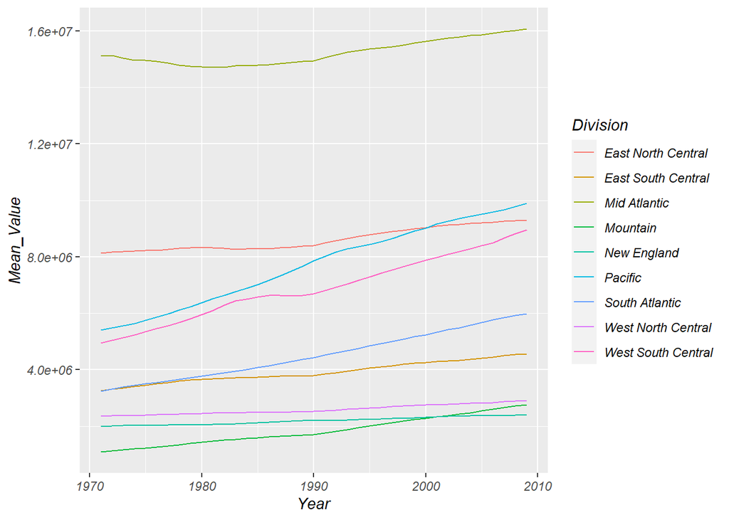

```r
plot.state(pst_state_abcd, var_name = 'Values')
```

#### County Plot : specifying the state to be “CT”, the group being the ‘top’, the number looked at being 6 i.e x=6

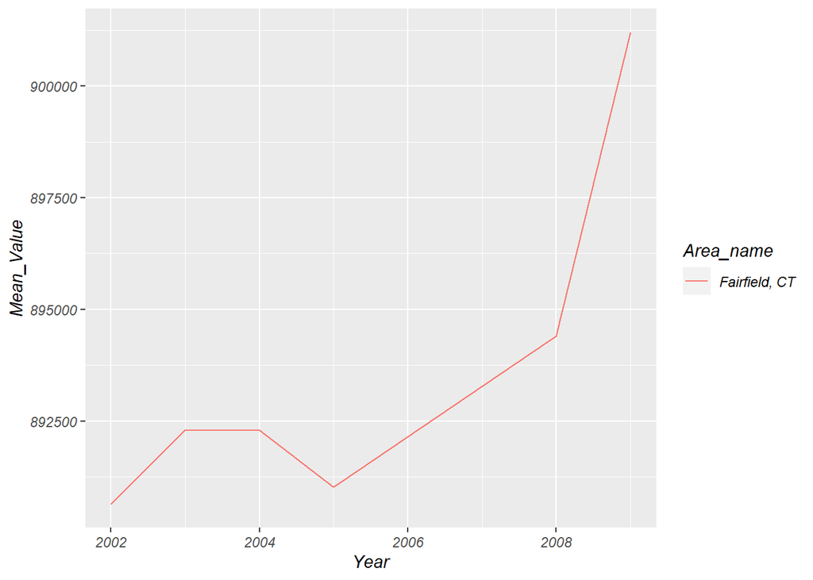

```r
plot.county(pst_county_abcd, var_name = 'Values',State='CT',how='top',x=6)
```

#### County Plot : specifying the state to be “NC”, the group being the ‘bottom’, the number looked at being 10 i.e x=10

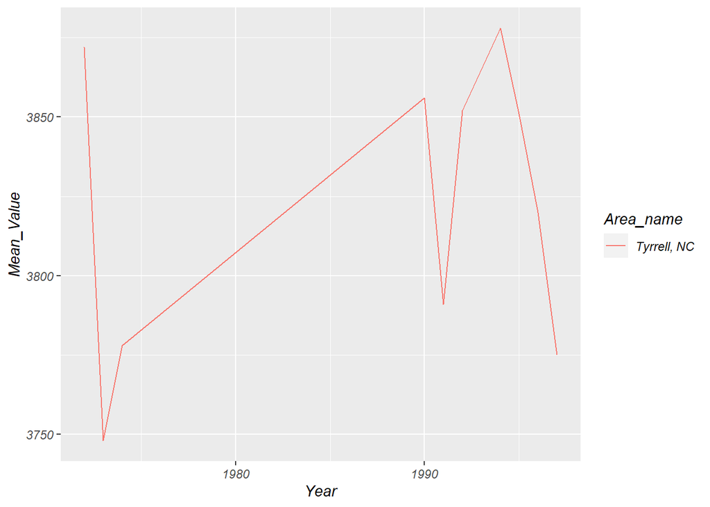

```r
plot.county(pst_county_abcd, var_name = 'Values',State='NC',how='bottom',x=10)
```

#### County Plot : without specifying anything (defaults used). State taken is ‘AL’ , ‘how’= ‘top’ and x=5.

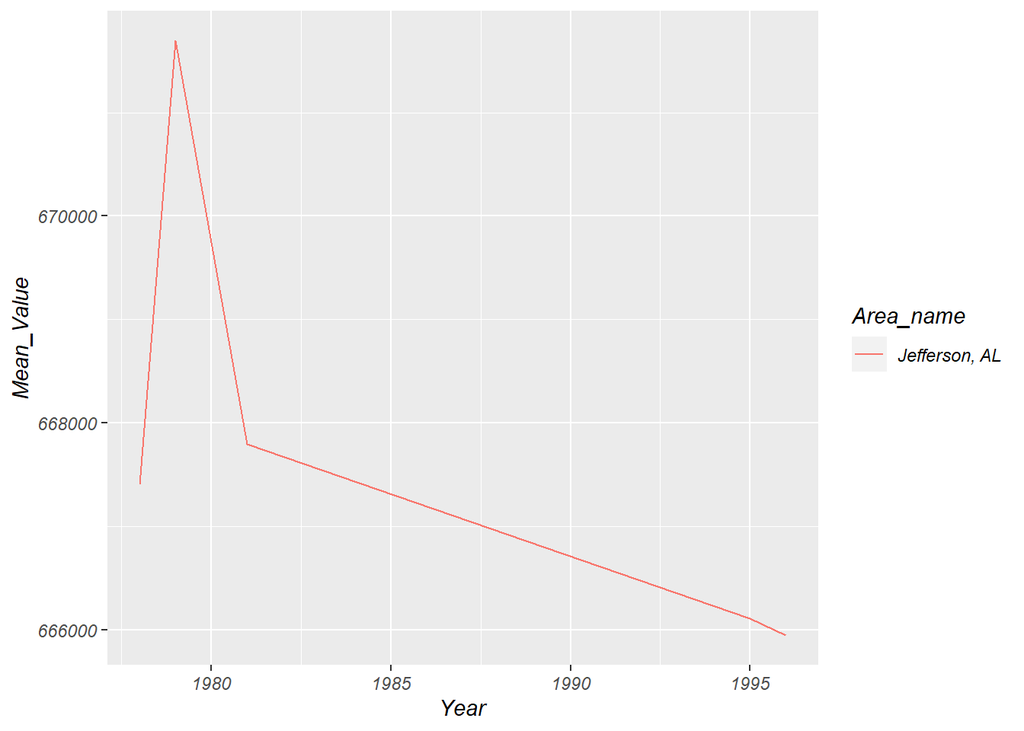

```r
plot.county(pst_county_abcd,var_name = 'Values')
```

#### County Plot : specifying the state to be “MN”, the group being the ‘top’, the number looked at being 4 i.e x=4

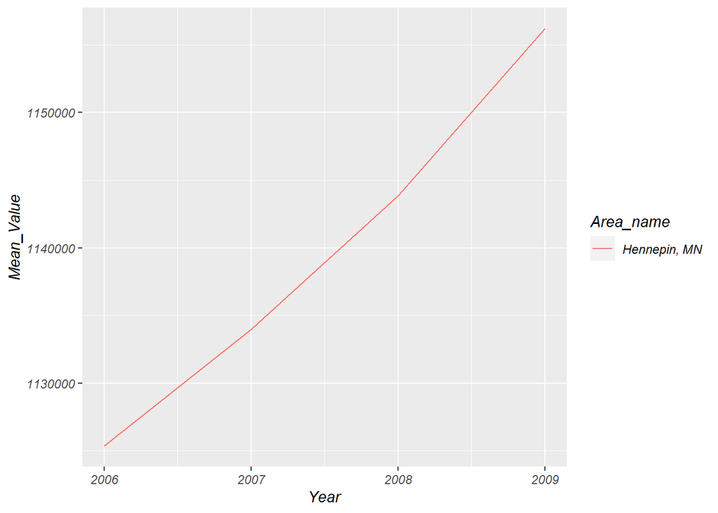

```r
plot.county(pst_county_abcd, var_name = 'Values',State='MN',how='top',x=4)
```